# Consensus cell types across samples from brain and CNS tumors

Ally Hawkins

2025-02-20

This notebook summarizes the consensus cell types identified in all samples from brain and CNS tumors that are part of ScPCA. This includes all samples from `SCPCP000001`, `SCPCP000002`, `SCPCP000010`, `SCPCP000021`, and all non-multiplexed samples from `SCPCP000009`.

We are interested in looking at any differences in cell composition across samples, with a particular interest in looking at the immune cell populations.

```r
suppressPackageStartupMessages({
  # load required packages
  library(ggplot2)
})

# Set default ggplot theme
theme_set(
  theme_classic()
)
```

## Data setup

```r
# The base path for the OpenScPCA repository, found by its (hidden) .git directory
repository_base <- rprojroot::find_root(rprojroot::is_git_root)
module_base <- file.path(repository_base, "analyses", "cell-type-consensus")

# results directory with cell-type-consensus
results_dir <- file.path(module_base, "results", "cell-type-consensus")

# data directory where project metadata files live
data_dir <- file.path(repository_base, "data", "current")
```

```r
# list all results files
brain_project_ids <- c("SCPCP000001", "SCPCP000002", "SCPCP000010", "SCPCP000021", "SCPCP000009")
brain_results_dirs <- file.path(results_dir, brain_project_ids)
results_files <- brain_results_dirs |>
  list.files(pattern = "_processed_consensus-cell-types\\.tsv.\\gz$", recursive = TRUE, full.names = TRUE)

# list project metadata files and grab only osteo metadata
metadata_files <- list.files(data_dir, pattern = "single_cell_metadata\\.tsv$", full.names = TRUE, recursive = TRUE)
metadata_ids <- fs::path_file(dirname(metadata_files))
names(metadata_files) <- metadata_ids
brain_metadata_files <- metadata_files[brain_project_ids]

# list of all immune cell types
consensus_immune_file <- file.path(module_base, "references", "consensus-immune-cell-types.tsv")
```

```r
# source summarize_celltypes() function
setup_functions <- file.path(module_base, "exploratory-notebooks", "utils", "setup-functions.R")
source(setup_functions)

# source stacked_barchart() and sina_plot() functions
plotting_functions <- file.path(module_base, "exploratory-notebooks", "utils", "plotting-functions.R")
source(plotting_functions)
```

```r
# get immune cell types
immune_df <- readr::read_tsv(consensus_immune_file)
immune_types <- immune_df$consensus_annotation

# read in metadata
all_metadata_df <- brain_metadata_files |>
  purrr::map(\(file) readr::read_tsv(file, col_types = list(.default = "c"))) |>
  dplyr::bind_rows() |>
  # select columns that might be useful
  dplyr::select(
    project_id = scpca_project_id,
    library_id = scpca_library_id,
    diagnosis,
    subdiagnosis,
    disease_timing,
    age,
    sex,
    tissue_location,
    seq_unit
  )

# define multiplexed libraries from SCPCP000009
non_multiplexed_libs <- c("SCPCL000531", "SCPCL000569", "SCPCL000570", "SCPCL000571")
multiplexed_libs <- all_metadata_df |>
  dplyr::filter(project_id == "SCPCP000009",
                !(library_id %in% non_multiplexed_libs)) |>
  dplyr::pull(library_id) |>
  unique()

# read in results and prep data frame for plotting
all_results_df <- results_files |>
  purrr::imap(summarize_celltypes) |>
  dplyr::bind_rows() |>
  # remove multiplexed libraries
  dplyr::filter(!(library_id %in% multiplexed_libs)) |>
  # join with sample metadata
  dplyr::left_join(all_metadata_df, by = c("project_id", "library_id"))
```

```r
# assign a color scheme for all bar charts

# get all possible cell types
# there are exactly 26 of them so we will use alphabet with two greys for unknown/all remaining
unique_celltypes <- all_results_df |>
  # order by frequency otherwise neurons will be light grey
  dplyr::arrange(desc(total_cells_per_annotation)) |>
  dplyr::filter(percent_cells_annotation > 0.1, # we're only ever going to plot cell types that are greater than 1%
                !consensus_annotation == "Unknown") |>
  dplyr::pull(consensus_annotation) |>
  unique() |>
  as.character()

# define colors for all cell types
all_celltype_colors <- c(
  palette.colors(palette = "alphabet"),
  "black", # extra cell type
  "grey60", # all remaining
  "grey95", # unknown
  "grey60" # non-immune, use the same as all remaining since they are never in the same plot
)
names(all_celltype_colors) <- c(unique_celltypes, "All remaining cell types", "Unknown", "non-immune")

# define a three color scheme for immune, other, and unknown
three_color_scheme <- c(
  "immune" = "navy",
  "non-immune" = "grey60",
  "Unknown" = "grey95"
)
```

## Composition of top cell types

Here we look at the top cell types identified across all samples. We have already looked at this in `02-explore-consensus-results.Rmd`, but here we will plot all samples from all brain and CNS projects ordered by the total percent of cells labeled with a consensus label.

```r
# add column of "top cell types" for easier plotting
all_results_df <- all_results_df |>
  dplyr::mutate(
    # get most frequently observed cell types across libraries in that project
    top_celltypes = forcats::fct_lump_n(consensus_annotation, 15, other_level = "All remaining cell types", ties.method = "first") |>
      # sort by frequency
      forcats::fct_infreq() |>
      # make sure all remaining and unknown are last, use this to assign colors in specific order
      forcats::fct_relevel("All remaining cell types", "Unknown", after = Inf),
  )
```

```r
# get a vector of library ids ordered by total percentage annotated
library_levels <- all_results_df |>
  dplyr::filter(consensus_annotation != "Unknown") |>
  dplyr::group_by(library_id) |>
  dplyr::summarize(
    total_percent_annotated = sum(total_cells_per_annotation)/unique(total_cells_per_library)
  ) |>
  dplyr::arrange(desc(total_percent_annotated)) |>
  dplyr::pull(library_id)

# append any libraries that have 0 cells annotated
non_annotated_libs <- setdiff(unique(all_results_df$library_id), library_levels)
library_levels <- c(library_levels, non_annotated_libs)

# reorder by total percentage annotated
all_results_df <- all_results_df |>
  dplyr::mutate(
    library_id = forcats::fct_relevel(library_id, library_levels)
  ) |>
  unique()
```

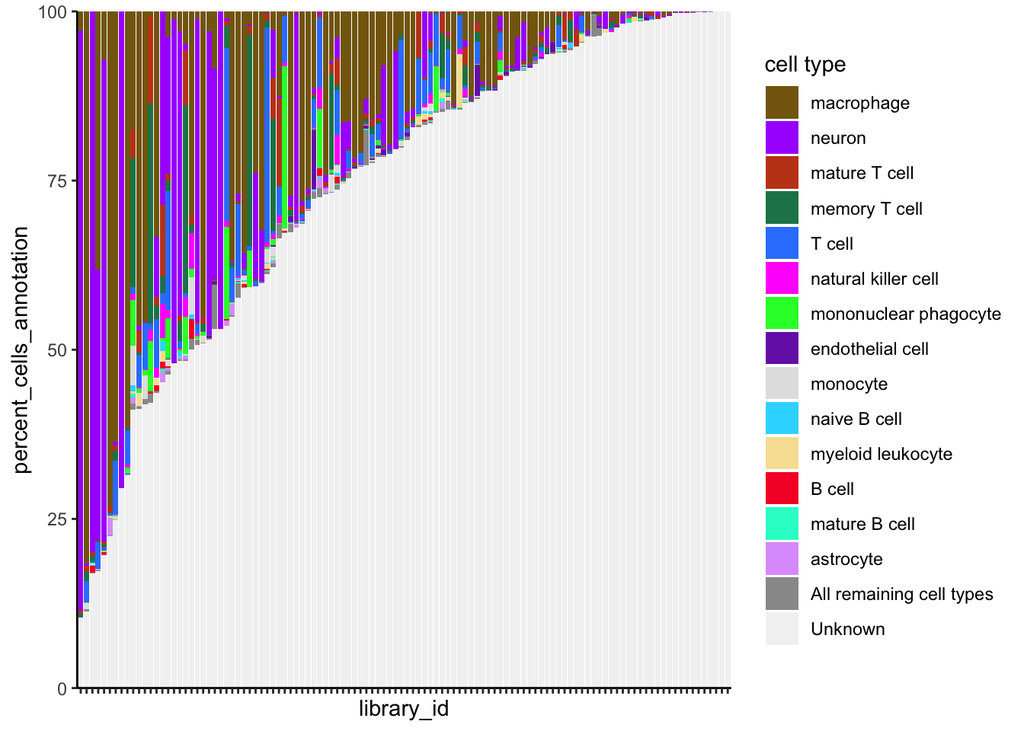

```r
stacked_barchart(all_results_df, fill_column = "top_celltypes", celltype_colors = all_celltype_colors)
```

Below we show the same data but faceted by project.

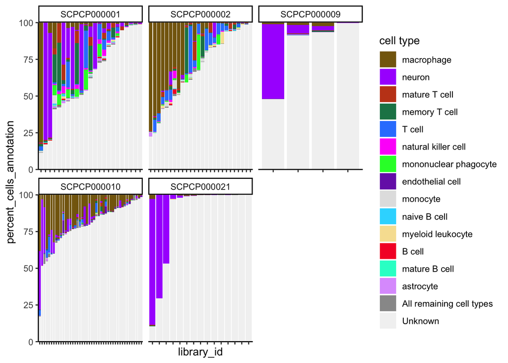

```r
stacked_barchart(all_results_df, fill_column = "top_celltypes", facet_variable = "project_id", celltype_colors = all_celltype_colors)
```

- Macrophages seem to be the dominant cell type across most samples.
- There appear to be some samples that have a higher proportion of T cells, but this is not project specific.
- As with the osteosarcoma samples there is some general heterogeneity both in the number of assigned cells and the cell types across all samples.

We hypothesize that there will be differences in the cell types observed based on the specific type of brain or CNS tumor. Let’s look at what tumor types are represented here and then use that to assign diagnosis groups so we can separate samples by diagnosis in the later plots.

```r
all_results_df |>
  dplyr::select(library_id, diagnosis) |>
  unique() |>
  dplyr::count(diagnosis, name = "number_of_samples") |>
  dplyr::arrange(desc(number_of_samples))
```

| diagnosis | number_of_samples |
| --- | --- |
| Low-grade glioma | 24 |
| Glioblastoma | 20 |
| Pilocytic astrocytoma | 18 |
| Ganglioglioma | 14 |
| High-grade glioma | 10 |
| Atypical teratoid rhabdoid tumor | 8 |
| Diffuse midline glioma | 3 |
| Infant-type hemispheric glioma | 3 |
| Ependymoma | 2 |
| Glial-neuronal tumor | 2 |

[output cut: 8 more lines]

Based on this let’s make the following groups:

- Low-grade glioma: Any samples labeled with “Low-grade glioma” or are part of `SCPCP000002` which are categorized as LGG tumors.
- High-grade glioma: Any samples labeled with “High-grade glioma”, “Diffuse midline glioma”, or are part of `SCPCP000001` which are categorized as HGG tumors.
- Glioblastoma
- Pilocytic astrocytoma
- Ganglioglioma
- ATRT
- Other: All samples that do not fall into the above categories.

We also have one “Non-cancerous” sample that we will keep separate.

```r
# assign diagnosis groups to use for faceting plots
all_results_df <- all_results_df |>
  dplyr::mutate(
    grouped_diagnosis = dplyr::case_when(
      diagnosis %in% c("Low-grade glioma", "Glioblastoma", "Pilocytic astrocytoma", "Ganglioglioma", "High-grade glioma", "Atypical teratoid rhabdoid tumor", "Non-cancerous") ~ diagnosis,
      project_id == "SCPCP000001" | diagnosis == "Diffuse midline glioma" ~ "High-grade glioma",
      project_id == "SCPCP000002" ~ "Low-grade glioma",
      .default =  "other"
    ) |>
      forcats::fct_relevel(c("other", "Non-cancerous"), after = Inf)
  )
```

Before we show the plots, let’s look at what samples are being grouped as “other”.

```r
all_results_df |>
  dplyr::filter(grouped_diagnosis == "other") |>
  dplyr::select(library_id, project_id, diagnosis, grouped_diagnosis) |>
  unique()
```

| library_id | project_id | diagnosis | grouped_diagnosis |
| --- | --- | --- | --- |
| SCPCL000570 | SCPCP000009 | Ependymoma | other |
| SCPCL000571 | SCPCP000009 | Dysplastic gangliocytoma | other |
| SCPCL000531 | SCPCP000009 | Dysembryoplastic neuroepithelial tumor | other |
| SCPCL000798 | SCPCP000010 | Glial-neuronal tumor | other |
| SCPCL000801 | SCPCP000010 | Focal cortical dysplasia | other |
| SCPCL000804 | SCPCP000010 | Glial-neuronal tumor | other |
| SCPCL000967 | SCPCP000021 | Infant-type hemispheric glioma | other |
| SCPCL000968 | SCPCP000021 | Infant-type hemispheric glioma | other |
| SCPCL000971 | SCPCP000021 | Infant-type hemispheric glioma | other |

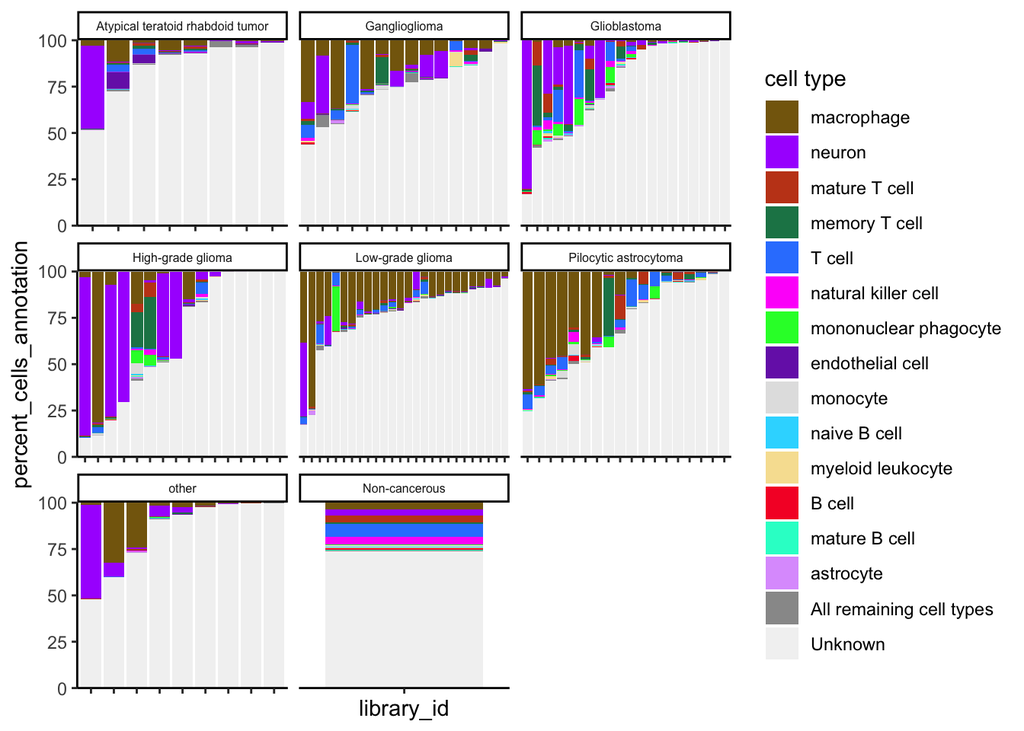

```r
stacked_barchart(all_results_df, fill_column = "top_celltypes", facet_variable = "grouped_diagnosis", celltype_colors = all_celltype_colors) +
  theme(strip.text = element_text(size = 6))
```

It looks like we do some qualitative differences between diagnosis groups! In particular, Glioblastoma seems to have the least amount of macrophages and favors T cells instead. ATRT also looks to generally have a lower amount of classified cells compared to other diagnoses.

Also a side note that there are a lot of “Unknown” cells in the “Non-cancerous” sample. I would have expected cell types there to be classified since we don’t have tumor, but this also might be a limit of the reference, we don’t have a lot of brain specific cell types outside of neuron and astrocyte.

## Immune cell populations

Let’s look specifically at immune cell populations. To do this we will lump all immune cells as “immune”, all non-immune as “non-immune”, and all unknown as “unknown”. Here we will sort by total percentage of immune cells.

```r
# look at immune cell types vs. unknown vs. other
all_results_df <- all_results_df |>
  dplyr::mutate(
    # first get a column that is just immune, unknown, or other
    immune_category = dplyr::case_when(
      consensus_annotation %in% immune_types ~ "immune",
      consensus_annotation == "Unknown" ~ "Unknown",
      .default = "non-immune"
    ),
    library_id = as.character(library_id) #remove existing levels
  )
```

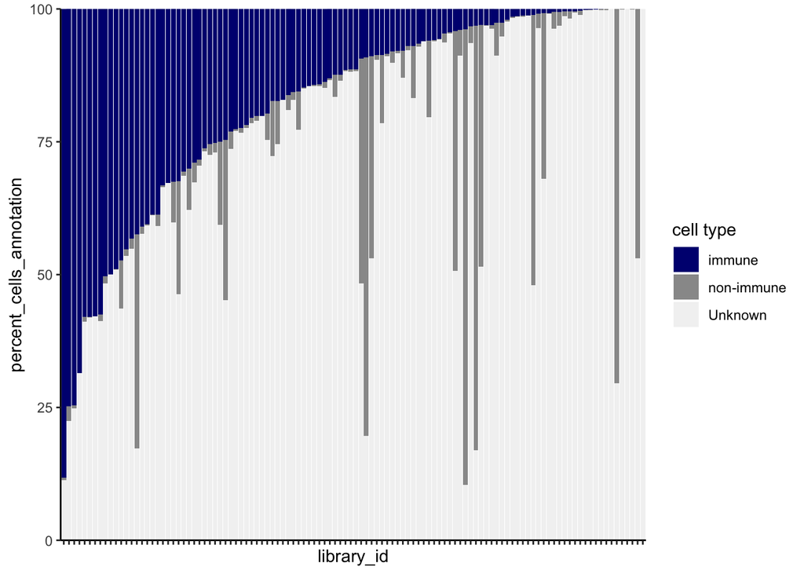

```r
# now sort just by immune percentage
immune_pct_df <- all_results_df |>
  dplyr::filter(immune_category == "immune") |>
  dplyr::mutate(annotation_percent_immune = total_cells_per_annotation/total_cells_per_library) |>
  dplyr::group_by(library_id) |>
  dplyr::summarize(
    percent_immune = sum(annotation_percent_immune)
  )

library_levels <- immune_pct_df |>
  dplyr::arrange(desc(percent_immune)) |>
  dplyr::pull(library_id)

# append any libraries that have 0 immune cells annotated
non_annotated_libs <- setdiff(unique(all_results_df$library_id), library_levels)
library_levels <- c(library_levels, non_annotated_libs)

immune_results_df <- all_results_df |>
  dplyr::left_join(immune_pct_df, by = c("library_id")) |>
  dplyr::mutate(
    percent_immune = dplyr::if_else(is.na(percent_immune), 0, percent_immune),
    library_id = forcats::fct_relevel(library_id, library_levels)
  )

stacked_barchart(immune_results_df, fill_column = "immune_category", celltype_colors = three_color_scheme)
```

Let’s see how the percentage of immune cells compares across projects and diagnosis.

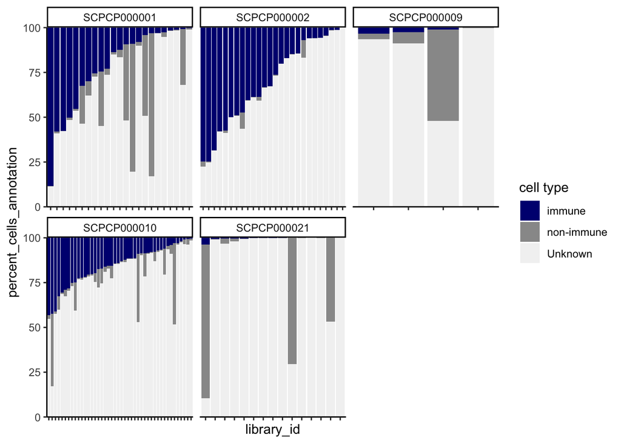

```r
stacked_barchart(immune_results_df, fill_column = "immune_category", facet_variable = "project_id", celltype_colors = three_color_scheme)
```

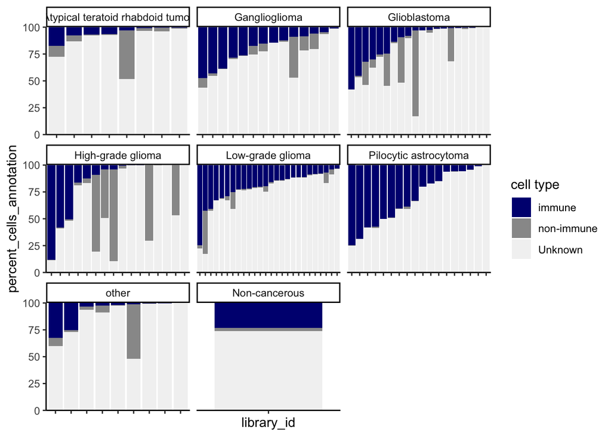

```r
stacked_barchart(immune_results_df, fill_column = "immune_category", facet_variable = "grouped_diagnosis", celltype_colors = three_color_scheme)
```

This isn’t super interesting to me since most classified cells are immune cells and there doesn’t seem to be any major differences across disease types outside of ATRT having a lower percentage of classified cells than other projects.

## Myeloid vs. T cell populations

It looks like there may be some differences between the presence of T cells and macrophages based on the tumor type. Here we will look specifically at all T cells and anything in the myeloid lineage, which includes macrophages, monocytes, mononuclear phagocytes, myeloid leukocytes, and neutrophils. We should also note that “macrophage” here probably refers to microglia instead.

```r
# t cell subtypes
t_cells <- unique_celltypes |>
  stringr::str_subset("T cell")

# macro/mono lineage
myeloid_cells <- c(
  "macrophage",
  "monocyte",
  "mononuclear phagocyte",
  "myeloid leukocyte",
  "neutrophil"
)

# create broad category for T cell vs. macro/mono
immune_results_df <- immune_results_df |>
  dplyr::mutate(
    immune_broad_category = dplyr::case_when(
      consensus_annotation %in% t_cells ~ "T cell",
      consensus_annotation %in% myeloid_cells ~ "Myeloid",
      consensus_annotation == "Unknown" ~ "Unknown",
      .default = "All remaining cell types"
    )
  )

# define colors
immune_category_colors <- c(
  "T cell" = all_celltype_colors[["T cell"]],
  "Myeloid" = all_celltype_colors[["macrophage"]],
  "All remaining cell types" = "grey60",
  "Unknown" = "grey90"
)
```

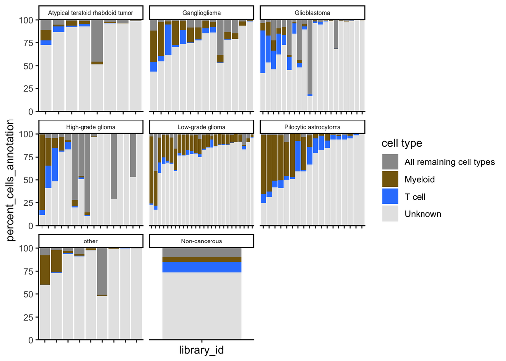

```r
stacked_barchart(immune_results_df, fill_column = "immune_broad_category", facet_variable = "grouped_diagnosis", celltype_colors = immune_category_colors) +
  theme(strip.text = element_text(size = 6))
```

- As expected based on the previous plot, glioblastoma appears to have a higher proportion of T cells when compared to myeloid cells across all samples.
- There appears to be a handful of samples in the “High-grade glioma” group that also have high T cell infiltrate. Notably, glioblastoma is a type of HGG.
- Generally, the T cell population seems lowest in LGG. Ganglioglioma also has fewer samples with high percentage of T cell infiltrate and this is also a LGG.
- It looks like about 50% of the pilocytic astrocytomas have more T cells than myeloid cells.

Finally, let’s group by either HGG or LGG.

```r
# assign diagnosis groups to use for faceting plots
hgg_lgg_df <- immune_results_df |>
  dplyr::mutate(
    hgg_vs_lgg = dplyr::case_when(
      grouped_diagnosis %in% c("Low-grade glioma", "Pilocytic astrocytoma", "Ganglioglioma") ~ "Low-grade glioma",
      grouped_diagnosis %in% c("High-grade glioma", "Atypical teratoid rhabdoid tumor", "Glioblastoma") ~ "High-grade glioma",
      grouped_diagnosis == "Non-cancerous" ~ "Non-cancerous",
      .default =  "other"
    )
  ) |>
  dplyr::filter(
    hgg_vs_lgg %in% c("High-grade glioma", "Low-grade glioma")
  )
```

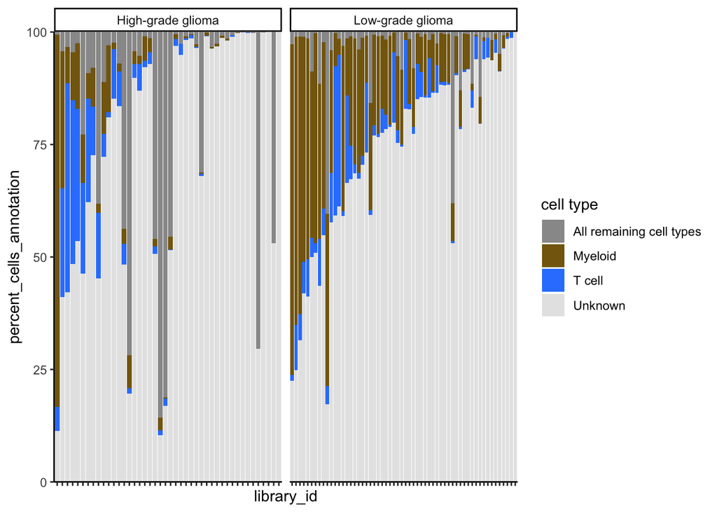

```r
stacked_barchart(hgg_lgg_df, fill_column = "immune_broad_category", facet_variable = "hgg_vs_lgg", celltype_colors = immune_category_colors)
```

Consistent with the previous findings it looks like HGG tend to have a higher proportion of T cells while LGG tend to have higher myeloid cell proportions.